# Regression - Separate Years

Ivan Patel

10/29/2020

## Visualizing the variables: 2010-2014

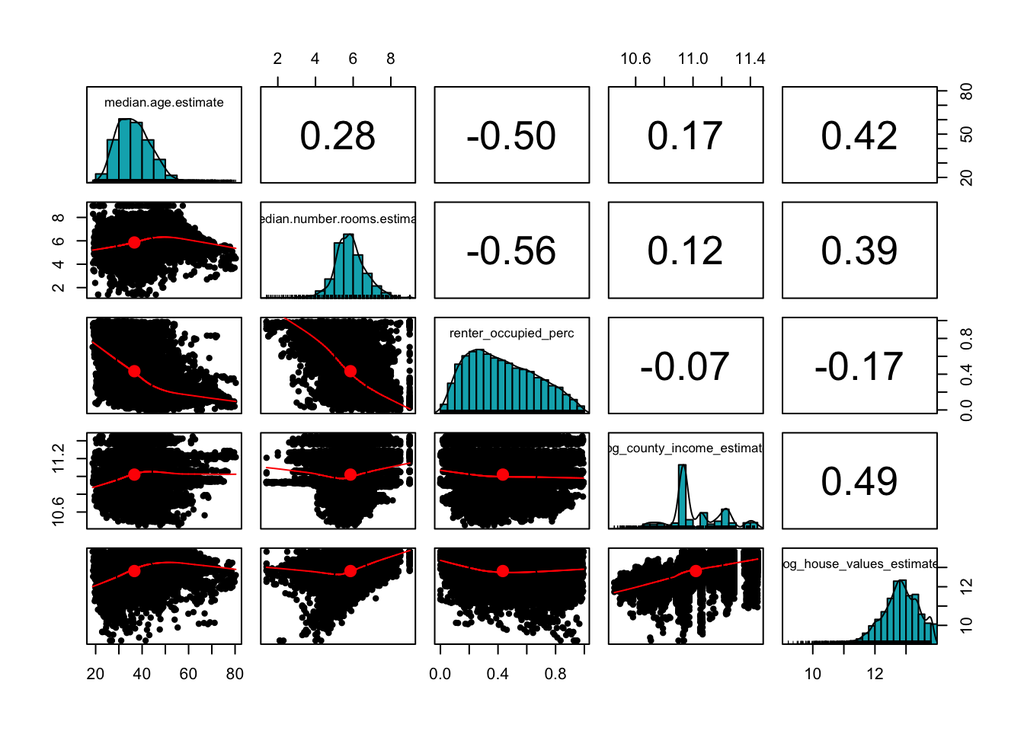

```r
# Pairs Plot
ols_model_2010_2014 %>%
  select(median.age.estimate:renter_occupied_perc, log_county_income_estimate,
         log_house_values_estimate) %>%

  pairs.panels(method = "pearson", # correlation method
             hist.col = "#00AFBB"
)
```

#### Why Heteroskedasticty will be an issue

The last row of the above plot is such that log house values are on the y-axis, and the other variables are on the x-axis.

Looking at the scatterplots of log house values v. median age, and log house values v. median rooms, the variance in house values decreases as age and rooms increases. In contrast, the variance in house values increases and log county income increases.

I also believe that the same pattern holds for 2015:2018

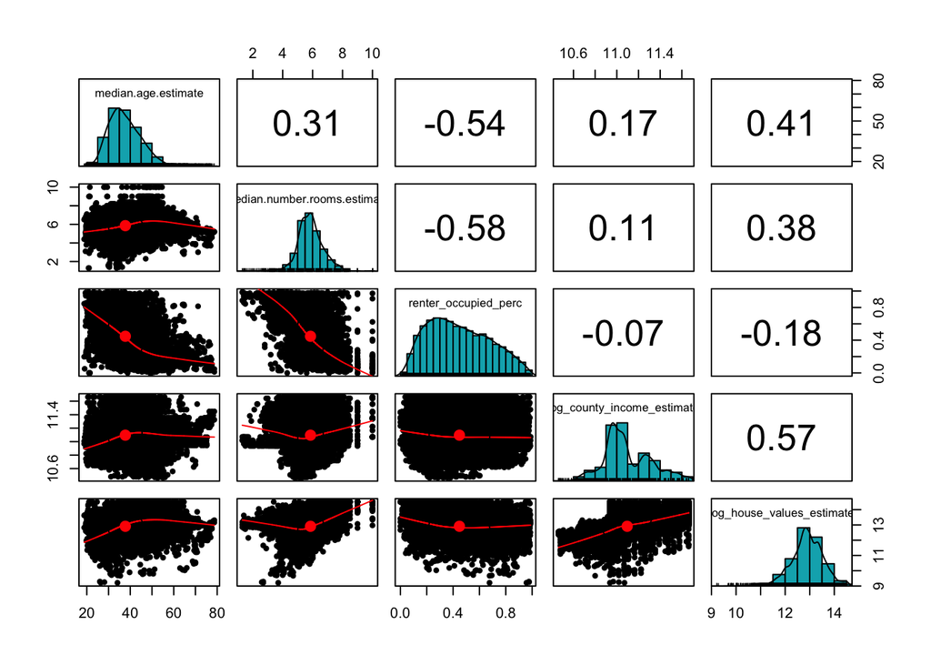

```r
ols_model_2015_2018 %>%
  select(median.age.estimate:renter_occupied_perc, log_county_income_estimate,
         log_house_values_estimate) %>%

  pairs.panels(method = "pearson", # correlation method
               hist.col = "#00AFBB"
  )
```

To make accurate inferences, I will be using Huber-White robust standard errors for both models.

Finally, I also looked at boxplots of all other variables with Coastal as it is a categorical column with three possible values: Coastal, Near Coastal, and Not Coastal.

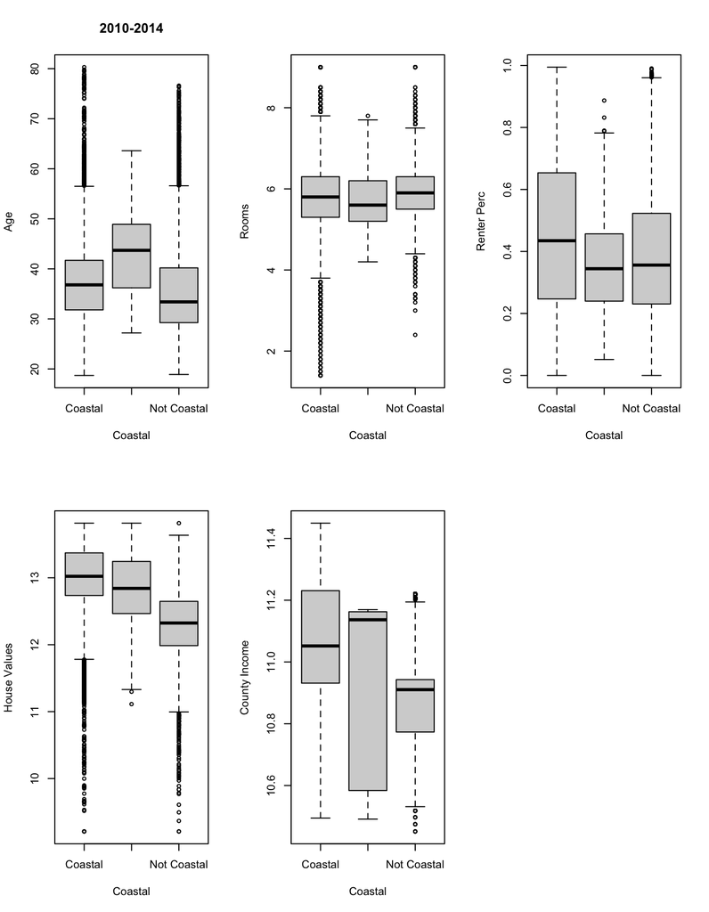

```r
# Boxplot of Coastal and other variables
par(mfrow=c(2,3))
boxplot(data=ols_model_2010_2014, median.age.estimate~Coastal, ylab='Age', main='2010-2014')
boxplot(data=ols_model_2010_2014, median.number.rooms.estimate~Coastal, ylab='Rooms')
boxplot(data=ols_model_2010_2014, renter_occupied_perc~Coastal, ylab='Renter Perc')
boxplot(data=ols_model_2010_2014, log_house_values_estimate~Coastal, ylab='House Values')
boxplot(data=ols_model_2010_2014, log_county_income_estimate~Coastal, ylab='County Income')
```

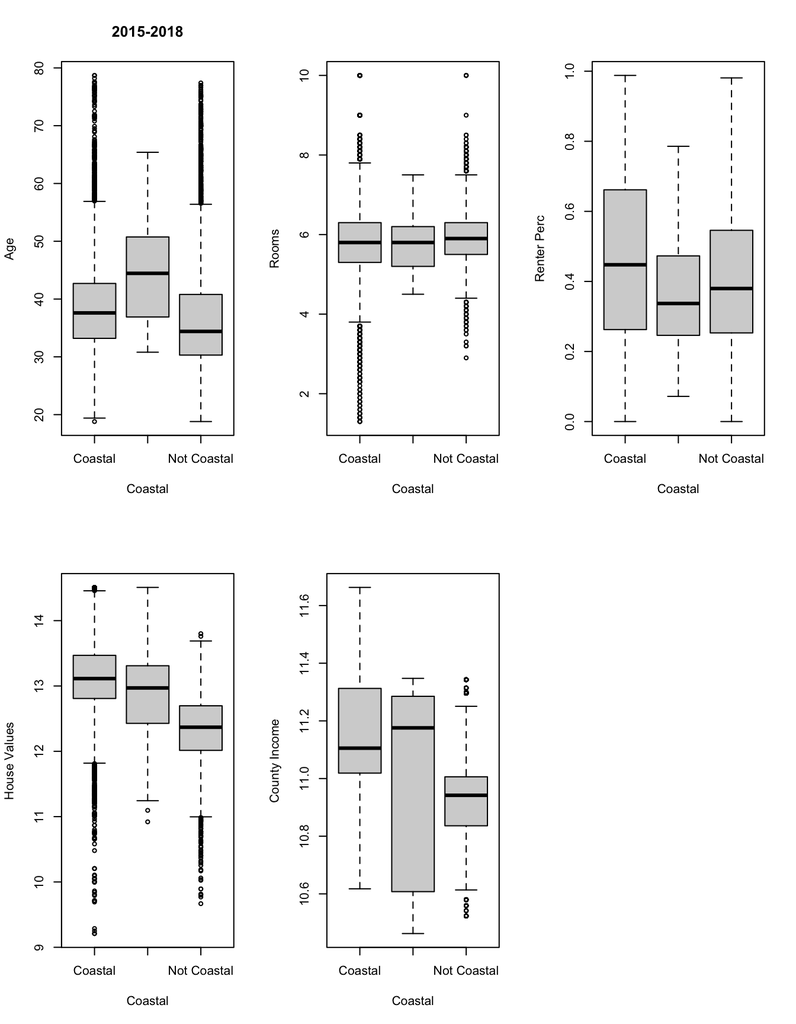

```r
par(mfrow=c(2,3))
boxplot(data=ols_model_2015_2018, median.age.estimate~Coastal, ylab='Age', main='2015-2018')
boxplot(data=ols_model_2015_2018, median.number.rooms.estimate~Coastal, ylab='Rooms')
boxplot(data=ols_model_2015_2018, renter_occupied_perc~Coastal, ylab='Renter Perc')
boxplot(data=ols_model_2015_2018, log_house_values_estimate~Coastal, ylab='House Values')
boxplot(data=ols_model_2015_2018, log_county_income_estimate~Coastal, ylab='County Income')
```

For both models, it makes a ton of sense to include an interaction term between coastal and renter occupied percentage, as well as an interaction between coastal and county income.

Finally, I expect influential values to play a role in biasing the regression coefficients. We will check the cooks’s distance for influential values.

# Let’s run the Regression: 2010:2014

```r
model_2010_2014 <- lm(data = ols_model_2010_2014, log_house_values_estimate ~ . +
                        renter_occupied_perc * Coastal +
                        log_county_income_estimate * Coastal +
                        log_county_income_estimate * renter_occupied_perc)
```

```r
model_2015_2018 <- lm(data = ols_model_2015_2018, log_house_values_estimate ~ . +
                        renter_occupied_perc * Coastal +
                        log_county_income_estimate * Coastal +
                        log_county_income_estimate * renter_occupied_perc)
```

```r
stargazer(coeftest(model_2010_2014, vcov. = vcovHC, type='HC1'),
          coeftest(model_2015_2018, vcov. = vcovHC, type='HC1'),
          type='text')
```

```
##
## ============================================================================
##                                                     Dependent variable:
##                                                 ----------------------------
##
##                                                      (1)            (2)
## ----------------------------------------------------------------------------
## CoastalNear Coastal                               -9.346***      -6.723***
##                                                    (0.734)        (0.714)
##
## CoastalNot Coastal                                -4.541***      -4.005***
##                                                    (0.303)        (0.291)
##
## median.age.estimate                                0.023***      0.024***
##                                                    (0.0004)      (0.0004)
##
## median.number.rooms.estimate                       0.282***      0.303***
##                                                    (0.004)        (0.004)
##
## renter_occupied_perc                               -1.134*       -1.610***
##                                                    (0.600)        (0.613)
##
## log_county_income_estimate                         0.380***      0.643***
##                                                    (0.025)        (0.027)
##
## CoastalNear Coastal:renter_occupied_perc          -0.312***      -0.372***
##                                                    (0.102)        (0.112)
##
## CoastalNot Coastal:renter_occupied_perc           -0.517***      -0.523***
##                                                    (0.025)        (0.027)
##
## CoastalNear Coastal:log_county_income_estimate     0.845***      0.598***
##                                                    (0.068)        (0.065)
##
## CoastalNot Coastal:log_county_income_estimate      0.381***      0.332***
##                                                    (0.028)        (0.026)
##
## renter_occupied_perc:log_county_income_estimate    0.150***      0.201***
##                                                    (0.054)        (0.055)
##
## Constant                                           6.070***      3.012***
##                                                    (0.276)        (0.295)
##
## ============================================================================
## ============================================================================
## Note:                                            *p<0.1; **p<0.05; ***p<0.01
```

## OLS Assumptions Plots: 2010:2014

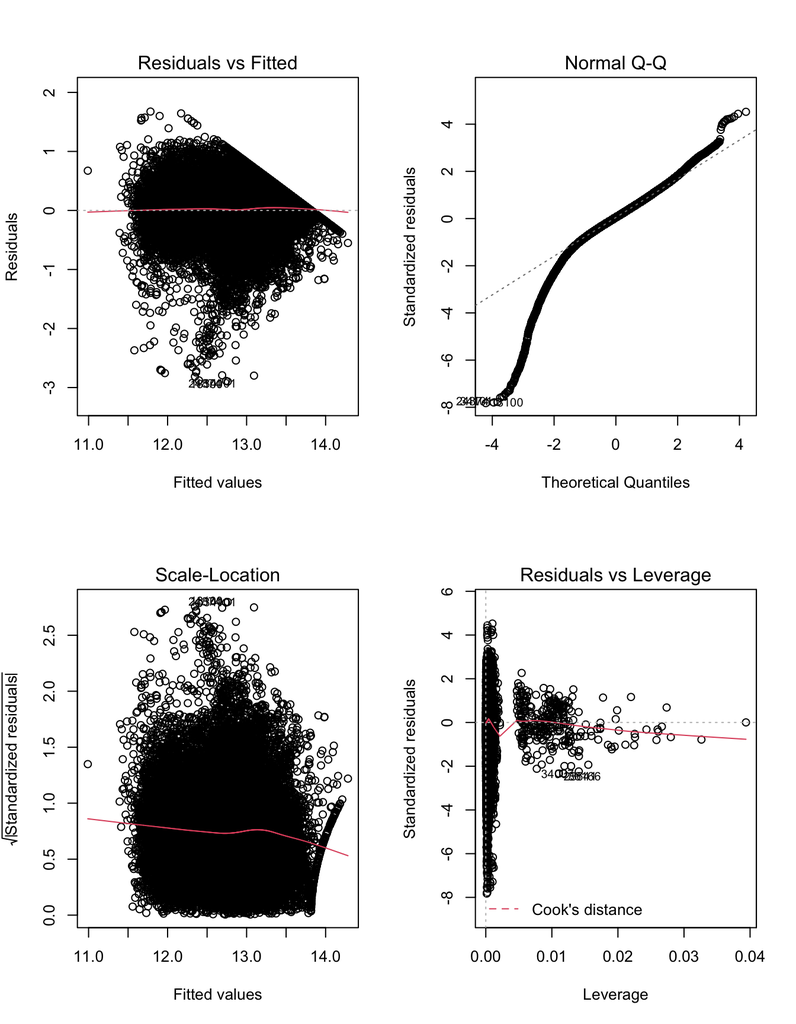

```r
par(mfrow = c(2, 2))
plot(model_2010_2014)
```

## OLS Assumptions Plots: 2015:2018

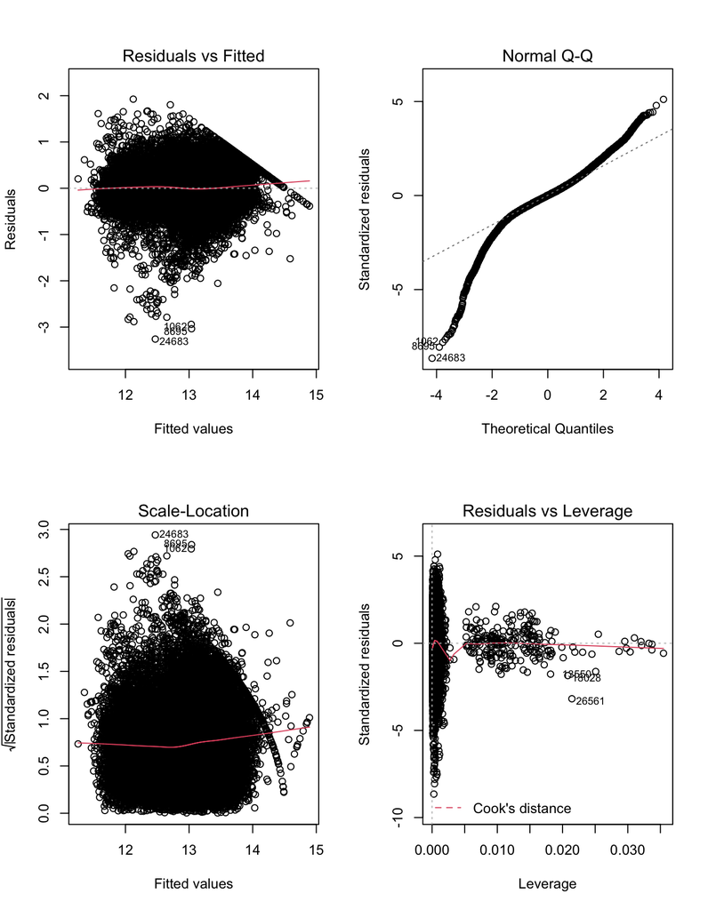

```r
par(mfrow = c(2, 2))
plot(model_2015_2018)
```